# Assignment_3

### Satelite in a low earth orbit (LEO)

As in the previous assignments we integrate the differential equation with the Runge-Kutta method (RK4). The satelite is in a approximate circular orbit with sentripetal acceleration $a=\frac{v^2}{r}$. From here we find our initial conditions $v_0 = \sqrt{\frac{G M_e}{r_0}}$. It is given that the satelite is at an altitude of 322km, so $r_0=6693$km.

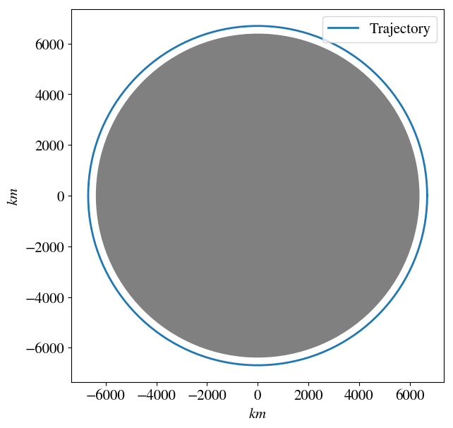

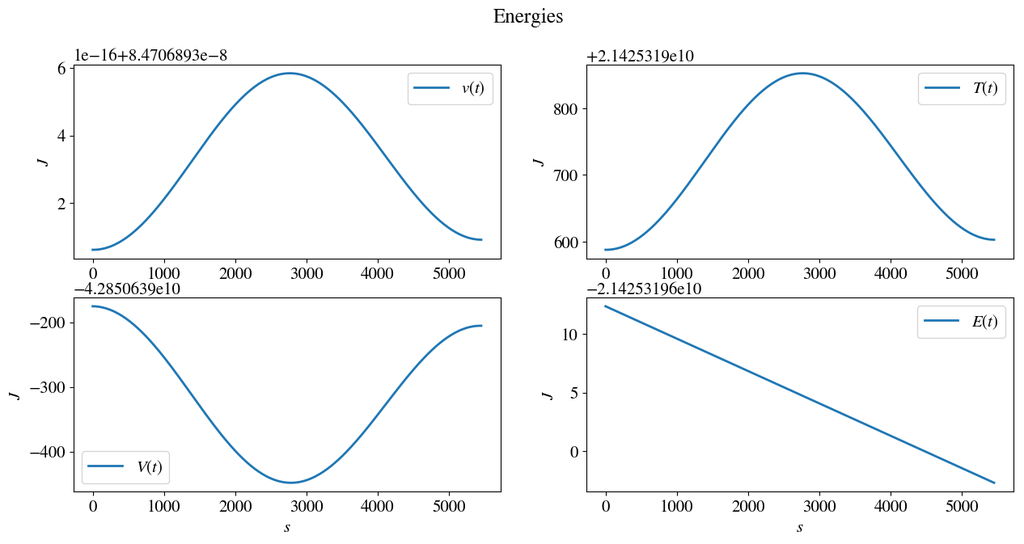

```python
import numpy as np
import matplotlib.pyplot as plt
newparams = {'figure.figsize': (15, 7), 'axes.grid': False,
             'lines.markersize': 10, 'lines.linewidth': 2,
             'font.size': 15, 'mathtext.fontset': 'stix',
             'font.family': 'STIXGeneral', 'figure.dpi': 100}
plt.rcParams.update(newparams)

G = 6.67e-11
M_e = 5.972e+24
m = 720

# p vektor = [v_x, v_y, x, y]
# tau = skrittlengde
# p' = f(p)
def f(p):
    return np.array([-G*M_e*p[2]*(p[2]**2+p[3]**2)**(-1.5),-G*M_e*p[3]*(p[2]**2+p[3]**2)**(-1.5),p[0],p[1]])

def step_RK(p, tau, f):
    k1 = f(p)
    k2 = f(p + (tau / 2) * k1)
    k3 = f(p + (tau / 2) * k2)
    k4 = f(p + tau * k3)
    return p + (tau / 6) * (k1 + (2 * k2) + (2 * k3) + k4)

def solve_ODE(t_0, p_0, t_end, tau, f, method):
    N = int((t_end-t_0)/tau)
    Times = np.linspace(t_0,t_end,N+1)
    P = np.zeros((N+1,len(p_0)))  # N+1 x 4 matrise
    P[0] = p_0
    for i in range(N):
        P[i+1] = method(P[i], tau, f)
    return Times, P

t_0 = 0
r_0 = 6693e+3
v_0 = np.sqrt((G*M_e)/r_0)
period = 2*np.pi*(r_0/v_0)
t_end = period   #=5451 seconds
tau = period/300
p_0 = np.array([0,v_0,r_0,0])

Times, P = solve_ODE(t_0, p_0, t_end, tau, f, step_RK)
def plot_trajectory(P):
    circle1 = plt.Circle((0, 0), 6.37e+3, color='grey')
    fig, ax = plt.subplots()

    ax.set_aspect(1)
    ax.add_artist(circle1)
    plt.plot(P[:,2]/1000,P[:,3]/1000,label="Trajectory")
    plt.xlabel("$km$")
    plt.ylabel("$km$")
    #plt.grid(linestyle='--')
    plt.legend(loc='upper right')
    plt.show()

plot_trajectory(P)
def get_Energies(Times, P):
    N = len(P[:,0])
    T = np.zeros(N)
    V = np.zeros(N)
    E = np.zeros(N)
    for i in range(N):
        T[i] = 0.5*m*(P[i,0]**2+P[i,1]**2)
        V[i] = -(G*M_e*m)/np.sqrt(P[i,2]**2+P[i,3]**2)
        E[i] = T[i] + V[i]
    return T, V, E

T, V, E = get_Energies(Times, P)

def plot_Energies(T,V,E,Times,label):
    fig, axs = plt.subplots(2, 2)
    fig.suptitle(label)
    axs[0,0].plot(Times,np.sqrt(2*T/M_e),label=r"$v(t)$")
    axs[0,0].set_ylabel("$J$")
    axs[0,0].legend()
    axs[0,1].plot(Times,T,label=r"$T(t)$")
    axs[0,1].set_ylabel("$J$")
    axs[0,1].legend()
    axs[1,0].plot(Times,V,label=r"$V(t)$")
    axs[1,0].set_xlabel("$s$")
    axs[1,0].set_ylabel("$J$")
    axs[1,0].legend()
    axs[1,1].plot(Times,E,label=r"$E(t)$")
    axs[1,1].set_xlabel("$s$")
    axs[1,1].set_ylabel("$J$")
    axs[1,1].legend()
    plt.show()

plot_Energies(T,V,E,Times,"Energies")
```

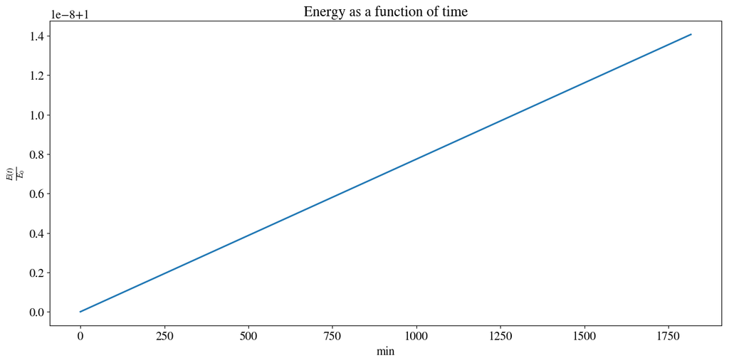

```python
Times, P = solve_ODE(t_0, p_0, 20*period, tau, f, step_RK)
T, V, E = get_Energies(Times, P)

plt.plot(Times/60,E/E[0])
plt.xlabel("min")
plt.ylabel(r"$\frac{E(t)}{E_0}$")
plt.title("Energy as a function of time")
plt.show()
```

The energy plot shows how the total energy changes for a long period of time, here 20$T$. Since the energy changes very little, by a factor of 10^-8, we can say that the solution is stable.

### Determining an appropriate time-step

Here we show two plots of the change in position after one full orbit, one with 'random' time-steps $\tau$ and one where the time-step is the period divided by an integer value $\tau = T/N$. The ladder option is ofcourse best and converge faster, atleast for stable orbits. This is similar to what we saw in the first assignment. Since we shall continue with finding the trajectory of a satelite changing orbits we must look at the first graph, with 'random' time-steps. By testing with different values of $\tau$ in the next tasks we found that a value of 5s and below is sufficient and gives a smooth curve.

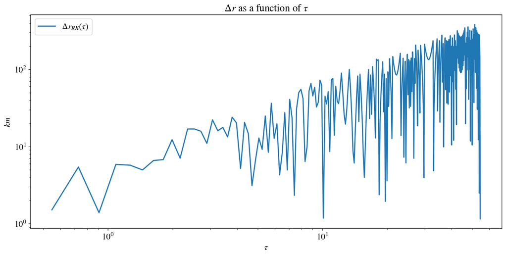

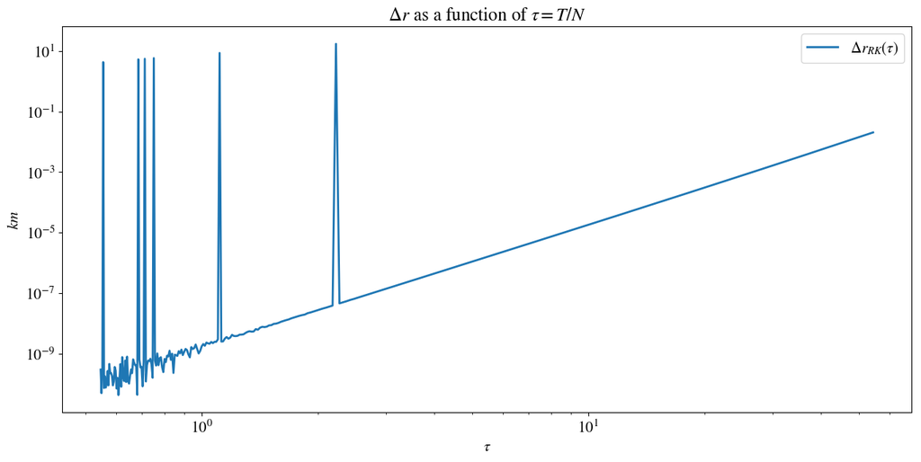

```python
def get_diff_pos(t_0, p_0, t_end, tau_array, f, method):
    diff_pos = np.zeros(len(tau_array))
    for i in range(len(tau_array)):
        Times, P = solve_ODE(t_0,p_0,t_end,tau_array[i],f,method)
        diff_pos[i] = np.sqrt((P[0,2]-P[-1,2])**2 + (P[0,3]-P[-1,3])**2)
    return diff_pos

tau_array = np.linspace(0.548,54.51,300)
Delta_r = get_diff_pos(t_0,p_0,period,tau_array,f,step_RK)

plt.xscale("log")
plt.yscale("log")
plt.plot(tau_array,Delta_r/1000, label=r"$\Delta r_{RK}(\tau )$")
plt.title(r"$\Delta r$ as a function of $\tau$")
plt.xlabel(r"$\tau$")
plt.ylabel("$km$")
plt.legend()
plt.show()

N = np.arange(1e+2,1e+4,50)
tau_array = period/N
Delta_r = get_diff_pos(t_0,p_0,period,tau_array,f,step_RK)

plt.xscale("log")
plt.yscale("log")
plt.plot(tau_array,Delta_r/1000, label=r"$\Delta r_{RK}(\tau )$")
plt.title(r"$\Delta r$ as a function of $\tau = T/N$")
plt.xlabel(r"$\tau$")
plt.ylabel("$km$")
plt.legend()
plt.show()
```

### Hohmann transfer

The satelite shall execute a transfer from a LEO, the same as earlier, to a geostationary orbit (GEO) with minimum energy consumption. The circular GEO has a radius of $r = 42051$km from the center of Earth. The satelite can only use two discrete velocity changes $\Delta v$ during the transfer. It turns out that the famous Hohmann transfer is the method with least energy conumption. The Hohmann transfer is explained and shown below.

```
t_2 =  18912.527
```

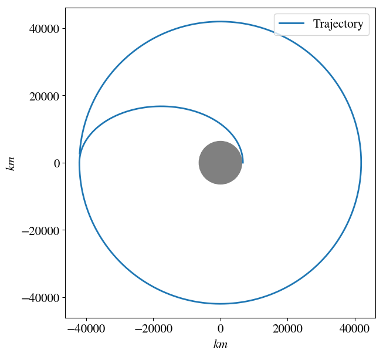

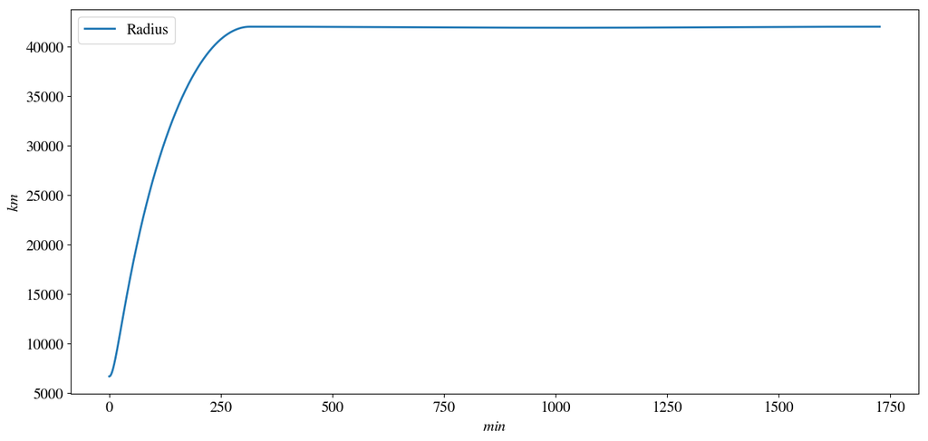

```
Final
	Radius; 42001.91 km.
	Velocity; 3077.63 m/s.
```

```python
def Hohmann_transfer(dv1,dv2,t_end,tau):
    N = int(t_end/tau)
    Times = np.linspace(t_0,t_end,N+1)
    P = np.zeros((N+1,len(p_0)))
    P[0] = p_0
    P[0,1] += dv1
    i = 0
    while i<N and P[i,3]>=0:
        P[i+1] = step_RK(P[i], tau, f)
        i += 1
    P[i,1] -= dv2
    print("t_2 = ", round(Times[i],3))
    for j in range(i,N):
        P[j+1] = step_RK(P[j], tau, f)
    return Times, P

t_end = 19*period  # uses the old LEO period as time-parameter
tau = 3

Times, P = Hohmann_transfer(2418,1463,t_end,tau)
plot_trajectory(P)

plt.plot(Times/60,np.sqrt(P[:,2]**2+P[:,3]**2)/1000,label="Radius")
plt.xlabel("$min$")
plt.ylabel("$km$")
plt.legend()
plt.show()

print("Final")
print("\tRadius;", round(np.sqrt(P[-1,2]**2+P[-1,3]**2)/1000,2), "km.")
print("\tVelocity;", round(np.sqrt(P[-1,0]**2+P[-1,1]**2),2), "m/s.")
```

In the Hohmann transfer our first thrust is at start where we increase the velocity in positive $y$-direction by $\Delta v_1 = 2.42$km/s. The satelite then travels an elliptic orbit until it reaches the apogee (farthest away from the Earth) which, in this case, is located a distance similiar to the radius of the new desirable circular orbit. The second thrust happens at the apogee in negative $y$-direction with magnitude $\Delta v_2 = 1.46$km/s. The satelite then continues in the geostationary orbit with an approximately constant radius.

The total velocity increase is then $\Delta v=3.88$km/s and the time between start and the second thrust is $t_2 = 18913 s = 315$ min.

An animation of the Hohmann transfer is shown below (which you hopefully can see).

[video not shown]

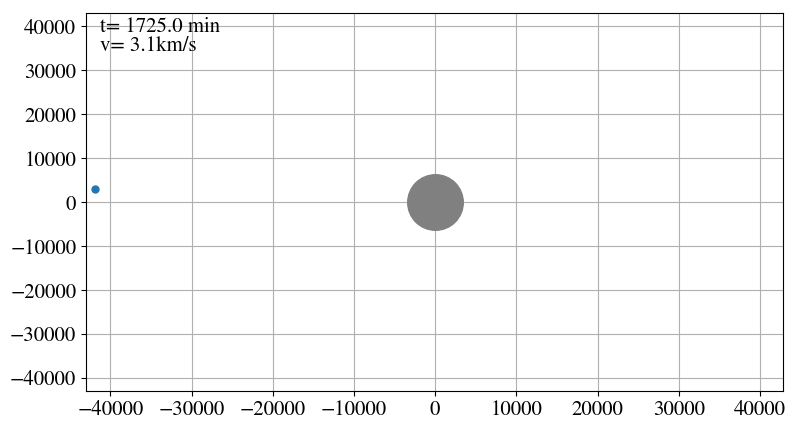

```python
from matplotlib import animation, rc
from IPython.display import HTML

v = np.sqrt(P[:,0]**2 + P[:,1]**2)
x = P[:,2]/1000
y = P[:,3]/1000

fig, ax = plt.subplots()
newparams = {'figure.figsize': (9, 5)}
plt.rcParams.update(newparams)
ax.grid()
ax.set_xlim((np.amin(x)-1e+3, np.amax(x)+1e+3))
ax.set_ylim((np.amin(y)-1e+3, np.amax(y)+1e+3))
time_text = ax.text(0.02, 0.95, '', transform=ax.transAxes)
speed_text = ax.text(0.02, 0.90, '', transform=ax.transAxes)

satelite, = ax.plot([], [], marker='o', markersize=5)
earth, = ax.plot(0,0,marker='o', markersize=40, color='grey')

def init():
    satelite.set_data([], [])
    time_text.set_text('')
    speed_text.set_text('')
    return satelite, time_text, speed_text

def animate(i):
    satelite.set_data(x[i], y[i])
    time_text.set_text('t= ' + str(round(Times[i]/60,0)) + ' min')
    speed_text.set_text('v= ' + str(round(v[i]/1000,1)) + 'km/s')
    return satelite,time_text,speed_text

fr = np.arange(0,len(Times),30)
anim = animation.FuncAnimation(fig, animate, init_func=init,frames=fr, interval=15, blit=True)
rc('animation', html='html5')
anim
```

### Counter examples

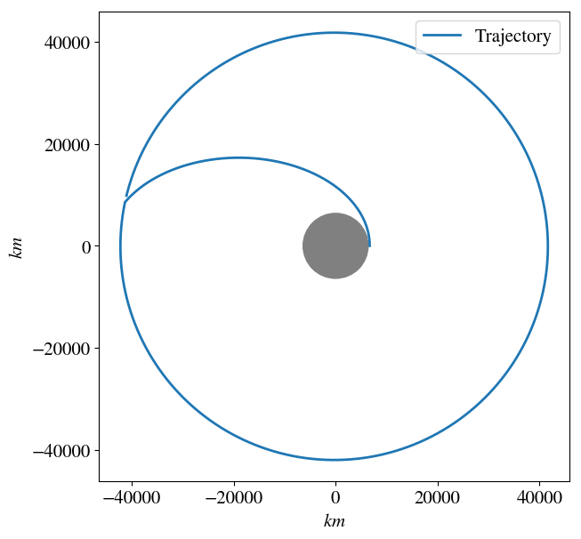

```
Final
	Radius; 42179.94 km.
	Velocity; 3063.69 m/s.
```

```python
def burn_fuel(thr1, thr2, t_end, tau):
    N = int(t_end/tau)
    Times = np.linspace(t_0,t_end,N+1)
    P = np.zeros((N+1,len(p_0)))
    P[0] = p_0
    i = 0
    while i<N and Times[i]<thr1[0]:
        P[i+1] = step_RK(P[i], tau, f)
        i += 1
    P[i,:2] += thr1[1:]
    while i<N and Times[i]<thr2[0]:
        P[i+1] = step_RK(P[i], tau, f)
        i += 1
    P[i,:2] += thr2[1:]
    for j in range(i,N):
        P[j+1] = step_RK(P[j], tau, f)
    return Times, P

t_end = 18.3*period
Times,P = burn_fuel([0,0,2460],[2.7*period,555,-1595],t_end,tau)
plot_trajectory(P)

print("Final")
print("\tRadius;", round(np.sqrt(P[-1,2]**2+P[-1,3]**2)/1000,2), "km.")
print("\tVelocity;", round(np.sqrt(P[-1,0]**2+P[-1,1]**2),2), "m/s.")
```

In the first counter-example we start with a larger initial thrust $\Delta v_1=2.46$km/s so the satelite don't reach the apogee at the radius of the geostationary orbit. For the second thrust we then need to change velocities in both $x$- and $y$-direction. In this case, the total net velocity change needed to reach GEO is $\Delta v=4.15$km/s.

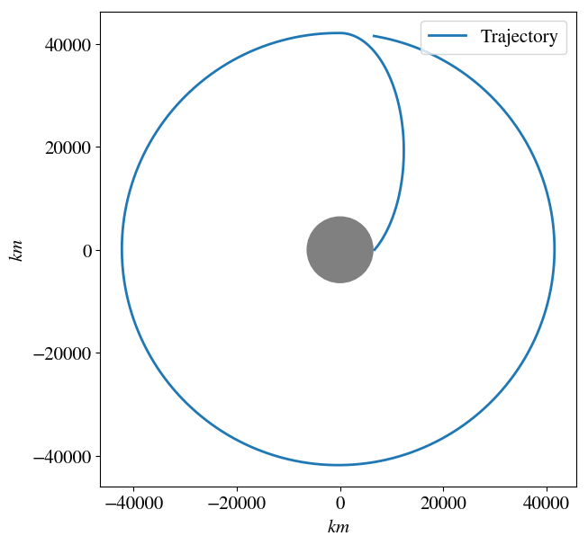

```
Final
	Radius; 42001.21 km.
	Velocity; 3076.91 m/s.
```

```python
t_end = 18.3*period
Times,P = burn_fuel([0,6487,0],[3*period,-1845,0],t_end,tau)
plot_trajectory(P)

print("Final")
print("\tRadius;", round(np.sqrt(P[-1,2]**2+P[-1,3]**2)/1000,2), "km.")
print("\tVelocity;", round(np.sqrt(P[-1,0]**2+P[-1,1]**2),2), "m/s.")
```

In this example we start with only increasing the velocity in $x$-direction. The satelite gets an elliptic orbit with the semi-major axis along the $y$-axis. Here we need a much larger velocity change to reach the apogee at the desired radius. After that we use the same method as for the Hohmann transfer where we increase the velocity at the apogee, here in negative $x$-direction. The total velocity change becomes $\Delta v = 8.33$km/s.